# Практикум 5 семестр Юрий Куринов 316 группа

[Ссылка на датасет](https://www.kaggle.com/datasets/timmofeyy/real-estate-in-moscow-for-sale-20220311?select=moscow_real_estate_sale.csv)

Данные представляют собой цены и хаарктеристики недвижимости в Москве.

**Ячейки с кодом Python помечены #python, в остальных - R.**

```r
oldw <- getOption("warn")
options(warn = -1)
set.seed(102030)


library("dplyr")
library("tidyr")
library("mice")
library("nortest")
library("outliers")
library("ISwR")
library("car")
library("knitr")
library("base")
library("pcaPP")
library("reticulate")
library("corrplot")
library("regclass")
library("glmnet")
library("coop")
```

```python
#python
import warnings

import matplotlib
import numpy as np
import pandas as pd
import matplotlib.pyplot as plt
import seaborn as sns

import statsmodels.api as sm
from statsmodels.stats.diagnostic import lilliefors
from statsmodels.stats.contingency_tables import mcnemar
from statsmodels.stats.outliers_influence import variance_inflation_factor
from statsmodels.tools.tools import add_constant

from pingouin import ttest

from scipy.stats import kstest, shapiro, anderson, cramervonmises, f_oneway, mannwhitneyu, levene, bartlett, fligner, pearsonr, spearmanr, kendalltau, chisquare, fisher_exact, norm

from sklearn.linear_model import LassoCV
from sklearn.model_selection import train_test_split
from sklearn.decomposition import PCA
from sklearn.metrics import mean_absolute_error
from sklearn.preprocessing import StandardScaler

from catboost import CatBoostRegressor

from outliers import smirnov_grubbs

from tensorflow import keras

warnings.filterwarnings('ignore')
sns.set(style="darkgrid")
```

#### **Читаю данные**

```r
quit
data <- read.csv(file="/Users/Юрий/Desktop/учёба/прак 5 сем/moscow_real_estate_sale.csv", stringsAsFactors = TRUE)
prices <- data$price
```

```python
reticulate::repl_python()
#python
df = pd.read_csv('/Users/Юрий/Desktop/учёба/прак 5 сем/moscow_real_estate_sale.csv', index_col=0)
```

# **1. Построение ядерных оценок плотности**

Красным представлено ядро Епанечникова $K(u) = \frac{3}{4}(1 - u^2)I(|u| \leq 1)$, синим - прямоугольное $K(u) = \frac{1}{2} I(|u| \leq 1)$

```r
quit
hist(prices, breaks = 1e4,
     main = "Распределение цен на недвижимость",
     xlim = c(0, 1e+8), xlab = "Цена",
     ylab = "Плотность")

lines(density(prices, kernel = "rectangular", width=1e-4, n=1024), col = "blue", lwd = 3)
```

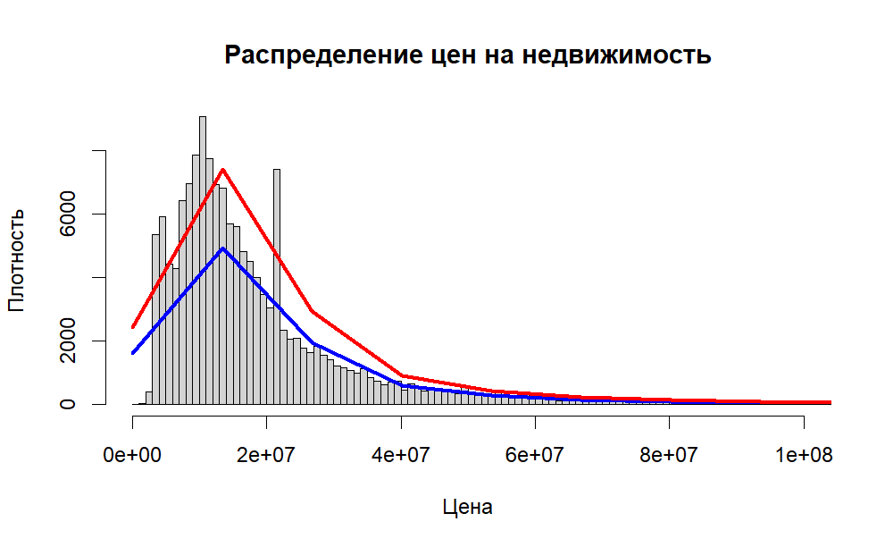

```r
lines(density(prices, kernel = "epanechnikov", width=1e-4, n=1024), col = "red", lwd = 3)
```

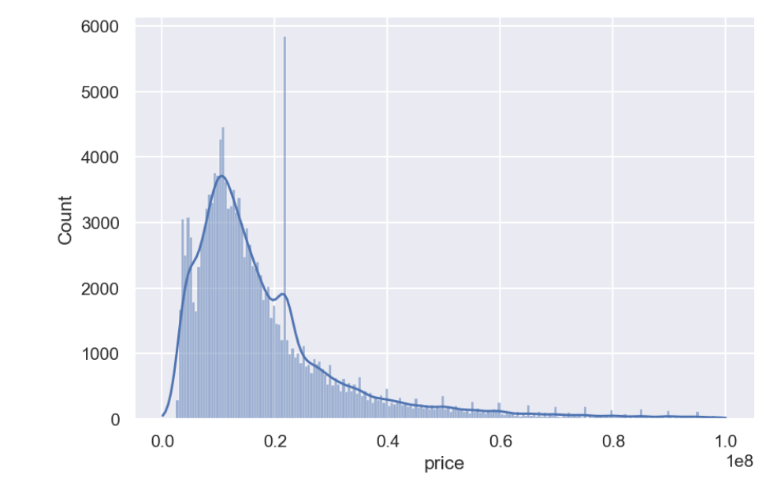

```python
reticulate::repl_python()
#python
p = sns.displot(data=df[df.price < 10**8], x='price', kde=True)
p.figure.set_size_inches((15, 5))
plt.show()
```

# **2. Анализ данных с помощью cdplot, dotcart, boxplot и stripchart**

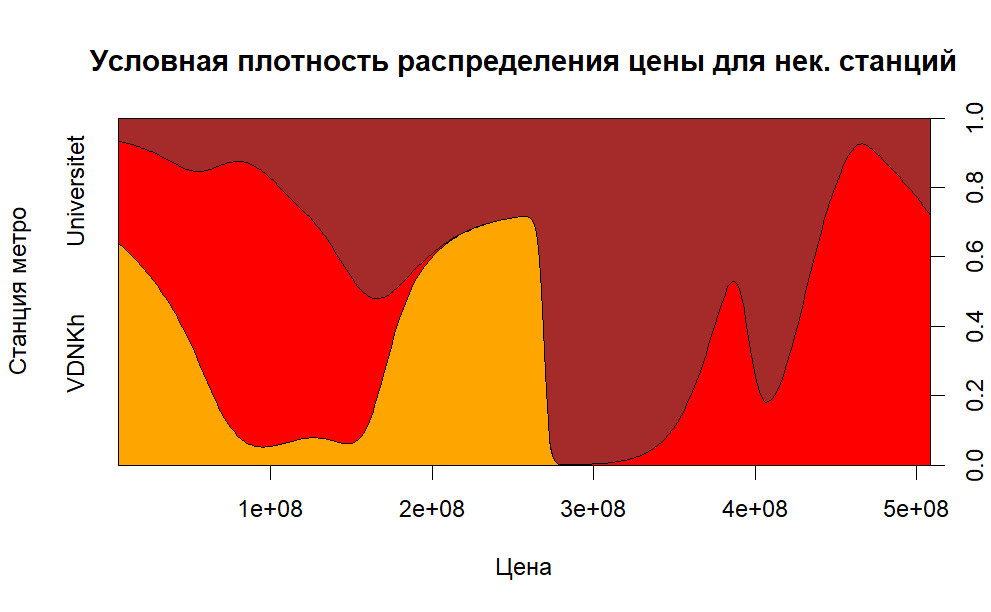

```r
quit
cdplot(main = "Условная плотность распределения цены для нек. станций", factor(data$metro, levels = c(" Taganskaia ", " Universitet ", " VDNKh ")) ~ data$price, col=c("orange", "red", "brown"), xlab = "Цена", ylab = "Станция метро")
```

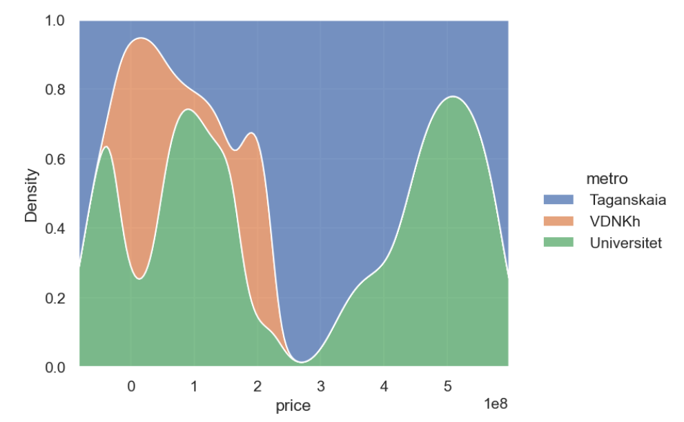

```python
reticulate::repl_python()
#python
p = sns.displot(x = 'price',
            data = df[(df.metro == ' Taganskaia ') | (df.metro ==  ' Universitet ') | (df.metro == ' VDNKh ')],
            hue = 'metro', kind='kde', multiple='fill')
plt.show()
```

**Выберем некоторые станции, чтобы сузить область анализа**

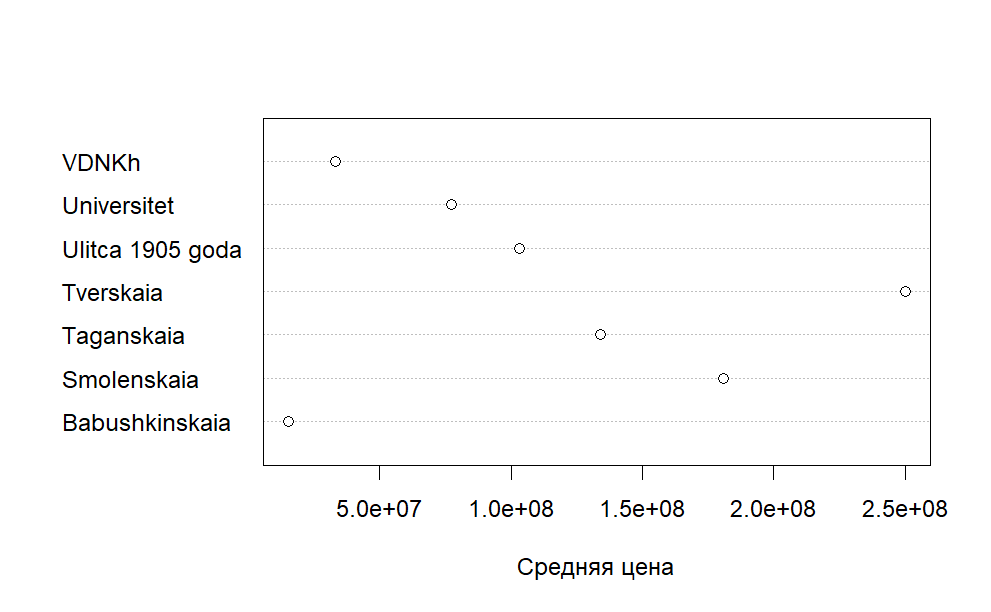

```r
quit
data_short = data[
  which(data$metro == " Taganskaia " |
          data$metro == " Universitet " |
          data$metro == " VDNKh " |
          data$metro == " Tverskaia " |
          data$metro == " Babushkinskaia " |
          data$metro == " Ulitca 1905 goda " |
          data$metro == " Smolenskaia "),
  ]

d0 = data_short %>% group_by(metro) %>% summarise(mean_price = mean(price))

dotchart(d0$mean_price, labels = d0$metro, xlab="Средняя цена")
```

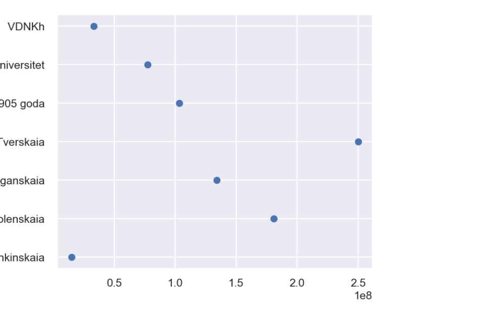

```python
reticulate::repl_python()
#python
plt.clf()
df_short = df[(df.metro == " Taganskaia ") |
          (df.metro == " Universitet ") |
          (df.metro == " VDNKh ") |
          (df.metro == " Tverskaia ") |
          (df.metro == " Babushkinskaia ") |
          (df.metro == " Ulitca 1905 goda ") |
          (df.metro == " Smolenskaia ")]

d0 = df_short.groupby('metro').price.mean()
plt.scatter(d0.values, d0.index)
plt.show()
```

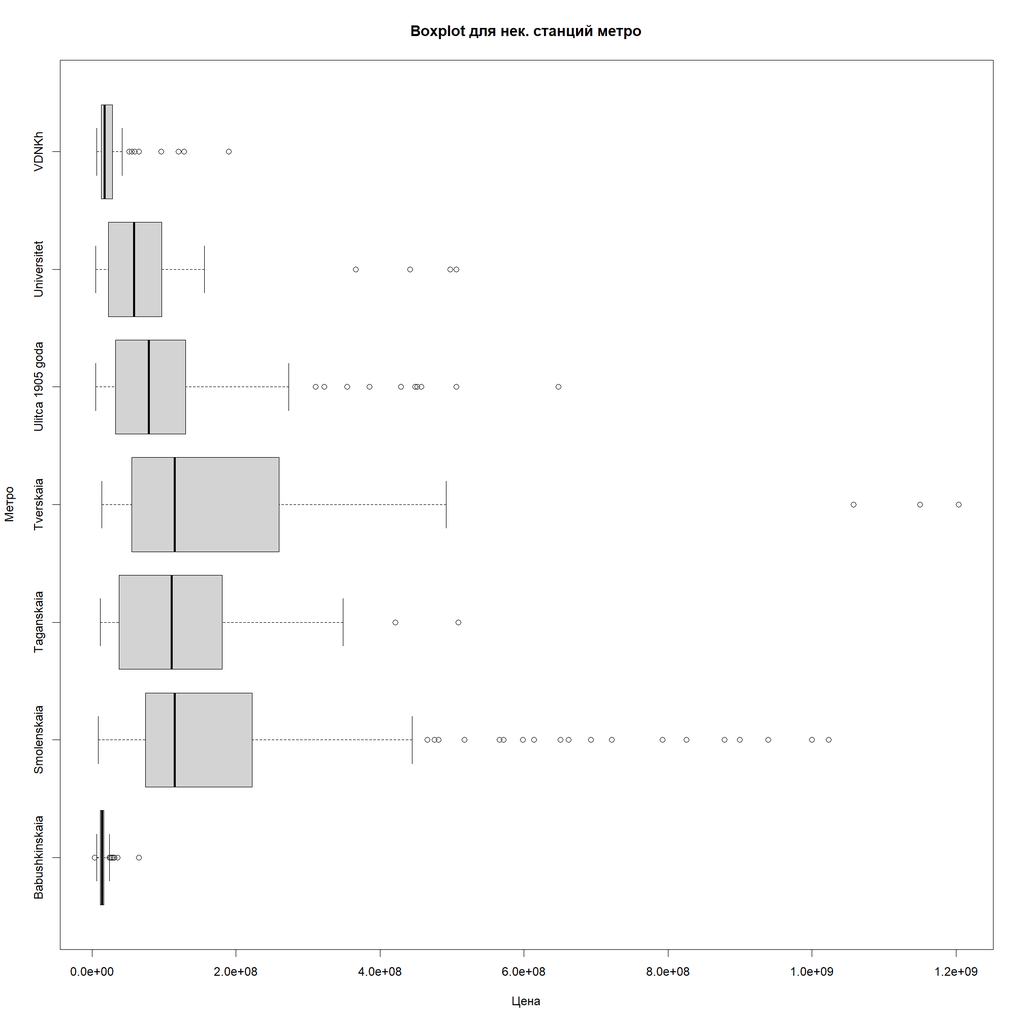

```r
quit
boxplot(price ~ metro, data = data_short, horizontal = TRUE, drop = TRUE, main = "Boxplot для нек. станций метро", xlab = "Цена", ylab = "Метро")
```

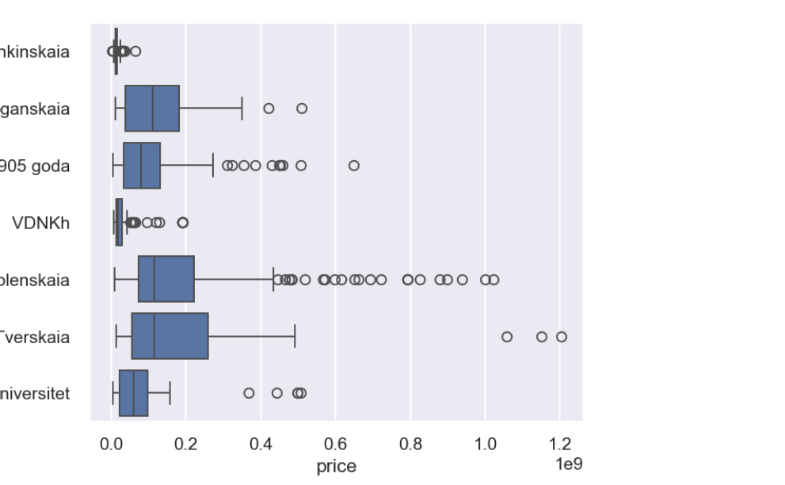

```python
reticulate::repl_python()
#python
plt.clf()
sns.boxplot(data=df_short, x='price', y='metro')
plt.show()
```

На Тверской среднее цены сильно больше, чем, например, на Смоленской, хотя их медианы почти совпадают (оно и понятно, т.к. среднее менее устойчиво к выбросам). Также, хорошо видна степень разброса цен.

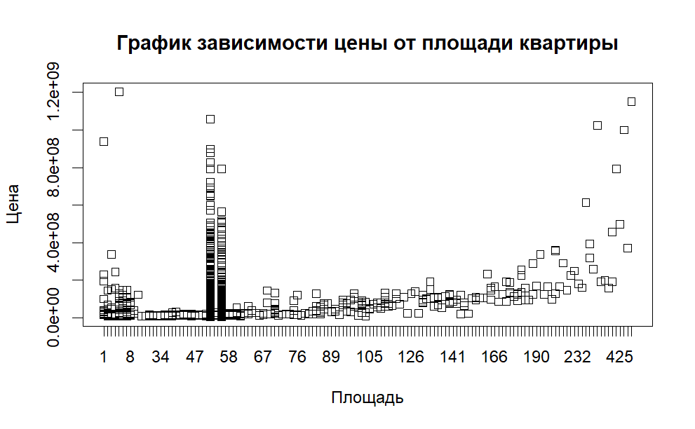

```r
quit
stripchart(price ~ total_area, data = data_short, vertical = TRUE, main = "График зависимости цены от площади квартиры", xlab = "Площадь", ylab = "Цена")
```

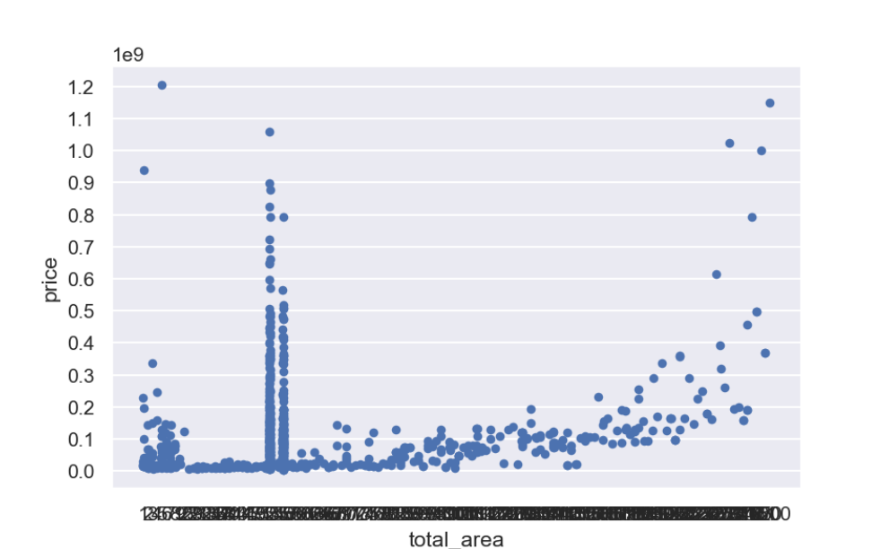

```python
reticulate::repl_python()
#python
plt.clf()
fig, ax = plt.subplots()
sns.stripplot(data=df_short, y='price', x='total_area')
plt.show()
```

Посмотрим, почему у некоторых квартир с площадью в диапазоне от 50 до 60 кв. м. очень большая цена.

```python
df[(df.price > 9*1e8) & (df.total_area < 60) & (df.total_area > 50)].metro.unique()
```

```
array([' Polianka ', ' Tretiakovskaia ', ' Park kultury ',
       ' Barrikadnaia ', ' Biblioteka im. Lenina ', ' Kievskaia ',
       ' Kropotkinskaia ', ' Frunzenskaia ', ' Sportivnaia ',
       ' Maiakovskaia ', ' Novokuznetckaia ', ' Pushkinskaia ',
       ' Minskaia ', ' Mezhdunarodnaia ', 'Outskirts', ' Trubnaia ',
       ' Kitai-gorod ', ' Tverskaia ', ' Chistye prudy '], dtype=object)
```

Станции метро в основном из центра города, это всё объясняет.